# [Заметки по R](http://bdemeshev.github.io/r_cycle/): Квантильная регрессия

24.03.2016

Подключим пакеты:

```r
library("quantreg") # квантильная регрессия
library("ggplot2") # графики
library("dplyr") # манипуляции с данными
```

Обычная регрессия предполагает, что условное среднее переменной $y$ линейно зависит от регрессора $x$:

$$E(y_i|x_i) = \beta_1 + \beta_2 x_i$$

Медианная регрессия предполагает, что от регрессоров линейно зависит условная медиана зависимой переменной:

$$Med(y_i|x_i)=\beta_1+\beta_2 x_i$$

Оценки медианной регрессии находятся путём минимизации суммы модулей. Если, как и в обычной регрессии, обозначить $\hat y_i = \hat\beta_1 + \hat\beta_2 x_i$, то целевая функция имеет вид:

$$\sum |y_i - \hat y_i| \to \min_{\hat\beta}$$

Обобщением медианной регрессии является квантильная регрессия. Квантильная регрессия предполагает, что условная квантиль порядка $\tau$ переменной $y$ линейно зависит от регрессора $x$:

$$q_{\tau}(y_i|x_i)=\beta_1+\beta_2 x_i$$

Здесь $q_{\tau}$ - это квантиль порядка $\tau$.

Задача оптимизации для квантильной регрессии имеет вид:

$$\sum w_i|y_i - \hat y_i| \to \min_{\hat\beta},$$
где веса $w_i$ показывают, насколько большой штраф получается в зависимости от того, перескочил ли прогноз $\hat y_i$ фактическое значение $y_i$

$$w_i =\begin{cases}
\tau, \text{ если } \hat y_i < y_i \\
1-\tau, \text{ если } \hat y_i \geq y_i
\end{cases}$$

Возьмём встроенный в R набор данных по стоимости бриллиантов и перейдем к логарифму цены бриллианта и логарифму массы:

```r
diams <- mutate(diamonds,
                log_price = log(price),
                log_carat = log(carat))
```

Оценим обычную и несколько квантильных регрессий:

```r
model_ols <- lm(data = diams, log_price ~ log_carat)
model_q <- rq(data = diams, log_price ~ log_carat,
              tau = c(0.01, 0.1, 0.5, 0.9, 0.99))
```

Посмотрим на описания всех пяти моделей

```r
summary(model_q)
```

```
##
## Call: rq(formula = log_price ~ log_carat, tau = c(0.01, 0.1, 0.5, 0.9,
##     0.99), data = diams)
##
## tau: [1] 0.01
##
## Coefficients:
##             Value     Std. Error t value   Pr(>|t|)
## (Intercept)   7.73780   0.02101  368.23594   0.00000
## log_carat     1.49805   0.02482   60.35184   0.00000
##
## Call: rq(formula = log_price ~ log_carat, tau = c(0.01, 0.1, 0.5, 0.9,
##     0.99), data = diams)
##
## tau: [1] 0.1
##
## Coefficients:
##             Value      Std. Error t value    Pr(>|t|)
## (Intercept)    8.13418    0.00219 3706.09415    0.00000
## log_carat      1.69432    0.00326  519.66516    0.00000
##
## Call: rq(formula = log_price ~ log_carat, tau = c(0.01, 0.1, 0.5, 0.9,
##     0.99), data = diams)
##
## tau: [1] 0.5
##
## Coefficients:
##             Value      Std. Error t value    Pr(>|t|)
## (Intercept)    8.43377    0.00156 5420.28232    0.00000
## log_carat      1.65124    0.00236  699.07418    0.00000
##
## Call: rq(formula = log_price ~ log_carat, tau = c(0.01, 0.1, 0.5, 0.9,
##     0.99), data = diams)
##
## tau: [1] 0.9
##
## Coefficients:
##             Value      Std. Error t value    Pr(>|t|)
## (Intercept)    8.80055    0.00306 2875.63314    0.00000
## log_carat      1.71922    0.00313  548.93883    0.00000
##
## Call: rq(formula = log_price ~ log_carat, tau = c(0.01, 0.1, 0.5, 0.9,
##     0.99), data = diams)
##
## tau: [1] 0.99
##
## Coefficients:
##             Value     Std. Error t value   Pr(>|t|)
## (Intercept)   9.15211   0.01928  474.77492   0.00000
## log_carat     1.83616   0.02236   82.11804   0.00000
```

В квантильной регрессии нет явных формул для оценок дисперсий коэффициентов. Существует несколько алгоритмов подсчёта оценок. По умолчанию используется алгоритм Губера, можно использовать бутстрэп, но он здесь очень долго думает:

```r
summary(model_q, se = "boot")
```

Можно на графике посмотреть, как меняются коэффициенты при изменении квантиля:

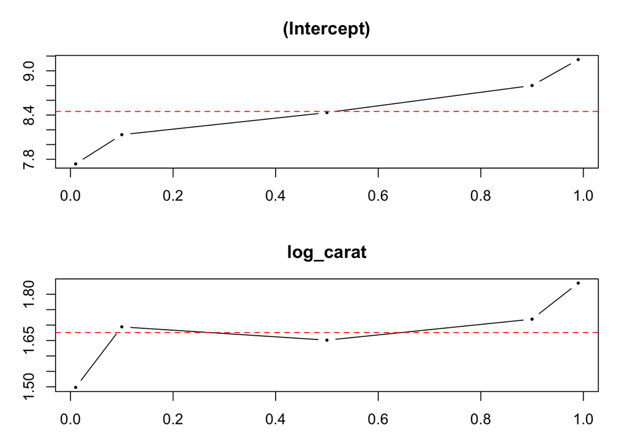

```r
plot(model_q)
```

На графике видно, что у самых дорогих бриллиантов цена более чувствительна к массе, чем у самых дешёвых. Для бриллиантов в среднем ценовом диапазоне эластичность цены по массе стабильна.

Изобразим на одном графике линию обычной регрессии и линии квантильных регрессий.

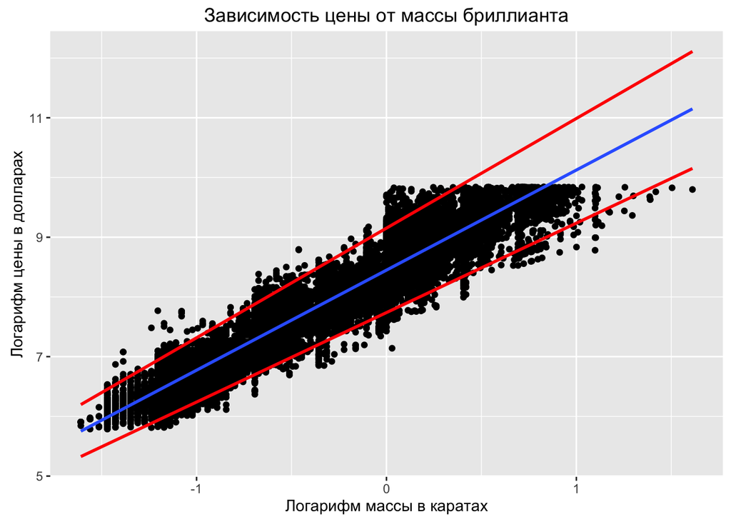

```r
base <- ggplot(data = diams, aes(x = log_carat, y = log_price)) +
  geom_point() + ggtitle("Зависимость цены от массы бриллианта") +
  xlab("Логарифм массы в каратах") + ylab("Логарифм цены в долларах")
base + stat_smooth(method = "lm", se = FALSE) +
  stat_smooth(method = "rq", se = FALSE, method.args = list(tau = 0.01), col = "red") +
  stat_smooth(method = "rq", se = FALSE, method.args = list(tau = 0.99), col = "red")
```

Без опции `se = FALSE` при методе `rq` вылезает ошибка.

Todo:

- Какой-нибудь пакет строит таблички для сравнения rq моделей рядом?
- Допилить mtable/texreg/broom?

Почиташки:

- Виньетка пакета quantreg